# Week 1

# Interpreting OLS Linear Regressions

## How can I compare the conditional means of all stores at once?

There are 45 distinct stores in this dataset. It would be painstaking to test for a true difference in means for each combination. Instead, we can run a quick OLS linear regression in a single line of code with summary(lm()). By factoring Store, the model creates a dummy variable for every level of the factor except the first, which is used as the reference case. Each estimate (or Beta) is the conditional mean of that level when added to the intercept of the model. A p-value is produced for each level, which describes whether the estimate is statistically significant. Here, we compare the output of the linear model with the independent conditional means of several test cases.

```r
#Check output of simple linear model
summary(lm(Weekly_Sales ~ factor(Store), data = df))
```

```
Call:
lm(formula = Weekly_Sales ~ factor(Store), data = df)

Residuals:
   Min     1Q Median     3Q    Max
-30306 -11980  -5775   4475 666767

Coefficients:
                Estimate Std. Error t value Pr(>|t|)
(Intercept)      21710.5      213.7 101.599  < 2e-16 ***
factor(Store)2    5187.5      302.2  17.163  < 2e-16 ***
factor(Store)3  -15337.5      312.1 -49.137  < 2e-16 ***
factor(Store)4    7450.7      302.0  24.671  < 2e-16 ***
factor(Store)5  -16657.1      312.5 -53.306  < 2e-16 ***
factor(Store)6     202.7      302.4   0.670    0.503
factor(Store)7  -13351.8      305.9 -43.646  < 2e-16 ***
factor(Store)8   -8577.5      304.9 -28.136  < 2e-16 ***
factor(Store)9  -12937.7      313.7 -41.240  < 2e-16 ***
factor(Store)10   4621.8      301.7  15.320  < 2e-16 ***
factor(Store)11  -2433.8      303.6  -8.017 1.08e-15 ***
factor(Store)12  -6843.2      306.4 -22.337  < 2e-16 ***
factor(Store)13   5644.6      300.5  18.782  < 2e-16 ***
factor(Store)14   7074.3      303.7  23.291  < 2e-16 ***
factor(Store)15 -12708.1      304.8 -41.692  < 2e-16 ***
factor(Store)16 -13847.3      308.5 -44.880  < 2e-16 ***
factor(Store)17  -8756.1      305.1 -28.699  < 2e-16 ***
factor(Store)18  -5977.2      305.1 -19.589  < 2e-16 ***
factor(Store)19  -1348.4      302.9  -4.451 8.53e-06 ***
factor(Store)20   7797.8      302.4  25.784  < 2e-16 ***
factor(Store)21 -10427.1      307.4 -33.923  < 2e-16 ***
factor(Store)22  -6529.3      306.5 -21.302  < 2e-16 ***
factor(Store)23  -1934.4      303.7  -6.370 1.89e-10 ***
factor(Store)24  -2741.4      302.3  -9.068  < 2e-16 ***
factor(Store)25 -11402.4      305.6 -37.315  < 2e-16 ***
factor(Store)26  -7156.4      305.2 -23.450  < 2e-16 ***
factor(Store)27   3116.4      302.3  10.308  < 2e-16 ***
factor(Store)28  -2995.7      303.2  -9.881  < 2e-16 ***
factor(Store)29 -13551.7      308.4 -43.936  < 2e-16 ***
factor(Store)30 -12946.3      333.2 -38.853  < 2e-16 ***
factor(Store)31  -2028.6      303.0  -6.696 2.14e-11 ***
factor(Store)32  -5358.9      302.5 -17.715  < 2e-16 ***
factor(Store)33 -15982.1      343.2 -46.571  < 2e-16 ***
factor(Store)34  -8188.5      302.3 -27.083  < 2e-16 ***
factor(Store)35  -7906.9      307.8 -25.686  < 2e-16 ***
factor(Store)36 -13126.1      347.6 -37.759  < 2e-16 ***
factor(Store)37 -11413.2      332.5 -34.322  < 2e-16 ***
factor(Store)38 -14218.1      330.5 -43.026  < 2e-16 ***
factor(Store)39   -709.8      305.0  -2.327    0.020 *
factor(Store)40  -7946.9      303.9 -26.149  < 2e-16 ***
factor(Store)41  -3734.5      303.4 -12.310  < 2e-16 ***
factor(Store)42 -10267.2      336.1 -30.551  < 2e-16 ***
factor(Store)43  -8295.4      339.0 -24.467  < 2e-16 ***
factor(Store)44 -15671.6      333.0 -47.057  < 2e-16 ***
factor(Store)45 -10047.6      306.9 -32.737  < 2e-16 ***
---
Signif. codes:  0 ‘***’ 0.001 ‘**’ 0.01 ‘*’ 0.05 ‘.’ 0.1 ‘ ’ 1

Residual standard error: 21630 on 421525 degrees of freedom
Multiple R-squared:  0.09321,   Adjusted R-squared:  0.09311
F-statistic: 984.7 on 44 and 421525 DF,  p-value: < 2.2e-16
```

```r
#Tidy output, rank, and compare
lm_simplified_output <- summary(lm(Weekly_Sales ~ factor(Store), data = df)) %>%
  tidy %>%
  select(term, estimate, p.value) %>%
  arrange(abs(estimate)) %>%
  mutate(p.value = round(p.value, 3), estimate = round(estimate, 1)) %>%
  slice(c(1:4,45))
#Create a conditional mean for each store in simplifed list
store1_mean <- df %>%
  filter(Store == 1) %>%
  select(Weekly_Sales) %>%
  unlist %>%
  mean
store6_mean <- df %>%
  filter(Store == 6) %>%
  select(Weekly_Sales) %>%
  unlist %>%
  mean
store39_mean <- df %>%
  filter(Store == 39) %>%
  select(Weekly_Sales) %>%
  unlist %>%
  mean
store19_mean <- df %>%
  filter(Store == 19) %>%
  select(Weekly_Sales) %>%
  unlist %>%
  mean
store23_mean <- df %>%
  filter(Store == 23) %>%
  select(Weekly_Sales) %>%
  unlist %>%
  mean
#Compare mean calculated from data with mean calculated from model output
lm_simplified_output %>%
  mutate(means_from_data = c(store6_mean, store39_mean, store19_mean, store23_mean, store1_mean),
         means_from_model = ifelse(term == "(Intercept)", estimate, estimate[5] + estimate)
         )
```

| term | estimate | p.value | means_from_data | means_from_model |
| --- | --- | --- | --- | --- |
| factor(Store)6 | 202.7 | 0.503 | 21913.24 | 21913.2 |
| factor(Store)39 | -709.8 | 0.020 | 21000.76 | 21000.7 |
| factor(Store)19 | -1348.4 | 0.000 | 20362.13 | 20362.1 |
| factor(Store)23 | -1934.4 | 0.000 | 19776.18 | 19776.1 |
| (Intercept) | 21710.5 | 0.000 | 21710.54 | 21710.5 |

## How can I interpret the output of my model?

The output for a simple linear regression is simple to interpret and useful for prediction and inference. Here, we review the available objects, some basic performance measures, and introductory diagnostics.

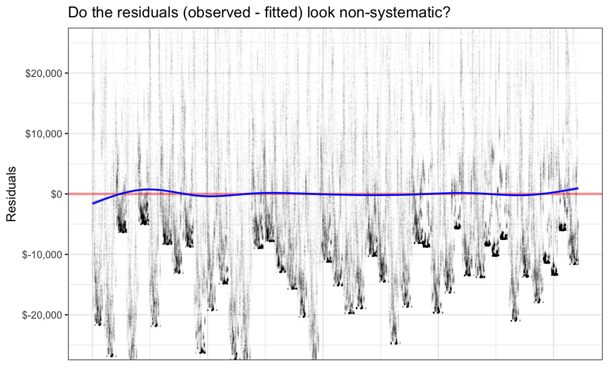

```r
data_frame(res = summary(lm1)$residuals, index = 1:length(summary(lm1)$residuals)) %>%
  ggplot(aes(index, res)) +
    geom_point(alpha = .01, size = .1) +
    geom_hline(yintercept = 0, color = "red", size = 1, alpha = .4) +
    geom_smooth(color = "blue", size = .7, se = T) +
    coord_cartesian(ylim = c(-25000, 25000)) +
    labs(title = "Do the residuals (observed - fitted) look non-systematic? ",
         y = "Residuals",
         x = element_blank()) +
    theme_bw() +
    theme(axis.text.x = element_blank(),
          axis.ticks.x = element_blank()) +
    scale_y_continuous(label = dollar)
#Look at 4 diagnostic plots. Clearly  these are some very strange diagnostics
par(mfrow = c(2,2)) # Change the panel layout to 2 x 2
print("Diagnostic plots for Store")
```

```
[1] "Diagnostic plots for Store"
```

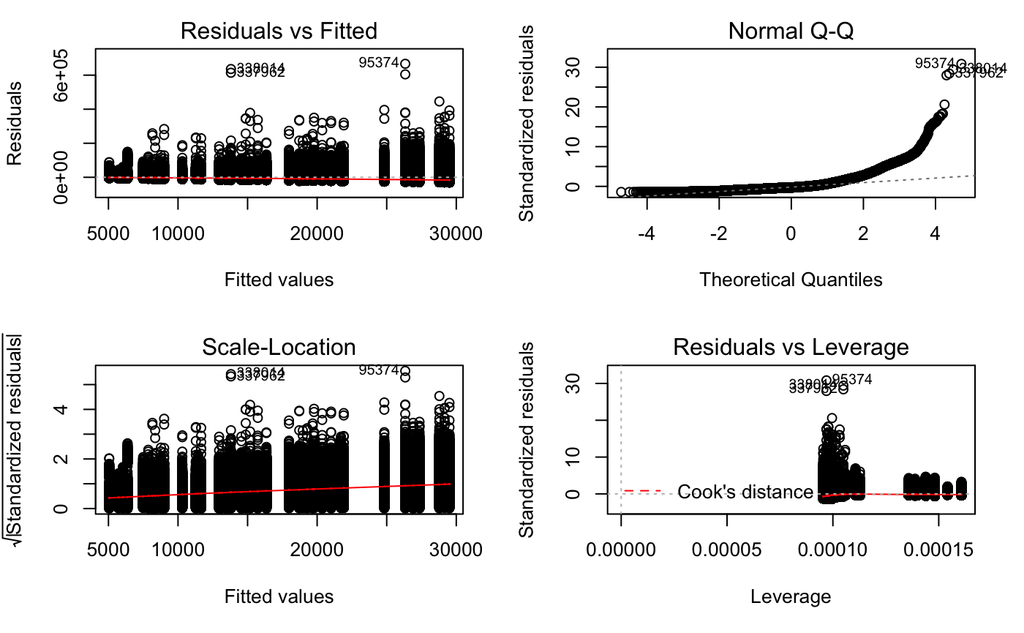

```r
plot(lm1)
```

# Controlling for other variables

The shortcoming of univariate regression is that it cannot account for other possible explanations. For example one might discover that there is a strong relationship between height likelihood of being incarcerated. However, when controlling for gender, we find that males are incarcerated at significantly higher rates than females and also tend to be taller. When the “control” (adding “gender” as another independent variable) is added to the model, the relationship between height and incarceration disappears, and it is found that gender is the explanatory variable.

## Is Store the only variable that affects weekly sales?

Similarly, we might hypothesize that if the week contains a significant holiday, that may influence the weekly sales. The holidays recorded are Superbowl, Labor Day, Thanksgiving, and Christmas. In the formula for the linear model, the dependent variable is on the left and the independent variable is on the right of the tilde. To add a control, simply append it with a plus sign as another independent variable. The first order of business is to factor all necessary variables and shuffle into random order. Next, interpret the results of the linear models with controls.

```r
#Factor necessary variables and basic feature engineering
df %<>% mutate(Store = factor(Store),
                  Dept = factor(Dept),
                  Type = factor(Type),
                  IsHoliday = factor(IsHoliday),
                  Holiday = ifelse(is.na(Holiday), "None", Holiday),
                  Holiday = factor(Holiday),
                  MarkDown1 = ifelse(is.na(MarkDown1), 0, MarkDown1),
                  MarkDown2 = ifelse(is.na(MarkDown2), 0, MarkDown2),
                  MarkDown3 = ifelse(is.na(MarkDown3), 0, MarkDown3),
                  MarkDown4 = ifelse(is.na(MarkDown4), 0, MarkDown4),
                  MarkDown5 = ifelse(is.na(MarkDown5), 0, MarkDown5),
                  Size = as.numeric(Size),
                  Month = factor(month(Date)),
                  Year = year(Date),
                  Quarter = factor(quarter(Date))
                  )
#Shuffle dataset into random order
df <- df[sample(1:nrow(df)), ]
####
#Sales on holiday weeks are an average of 1134 more and difference is statistically significant. Lets use IsHoliday as a control
summary(lm(Weekly_Sales ~ IsHoliday, data = df)) %>%
  tidy
```

| term | estimate | std.error | statistic | p.value |
| --- | --- | --- | --- | --- |
| (Intercept) | 15901.445 | 36.2754 | 438.353388 | 0.000000e+00 |
| IsHolidayTRUE | 1134.378 | 136.7585 | 8.294757 | 1.091222e-16 |

```r
#Notice that controlling for Holidays has very little effect on the conditional means of each store. In addition, the effect size of whether a week contains one of these four holidays is very small.  However, try replacing IsHoliday with Holiday and note the difference in the output.
controlled <- summary(lm(Weekly_Sales ~ Store + IsHoliday, data = df)) %>%
  tidy %>%
  mutate(IsStore = str_detect(term, "Store"), rank = rank(-abs(estimate)), control = 1) %>%
  filter(!IsStore | rank(-abs(estimate)) < 5) %>%
  select(rank, term, estimate, p.value)
uncontrolled <- summary(lm(Weekly_Sales ~ Store, data = df)) %>%
  tidy %>%
  mutate(IsStore = str_detect(term, "Store"),
         rank = rank(-abs(estimate)),
         control = 0) %>%
  filter(!IsStore | rank(-abs(estimate)) < 5) %>%
  select(rank, term, estimate, p.value)
controlled %>%
  bind_rows(uncontrolled)
```

| rank | term | estimate | p.value |
| --- | --- | --- | --- |
| 1 | (Intercept) | 21631.05 | 0.000000e+00 |
| 2 | Store5 | -16657.74 | 0.000000e+00 |
| 3 | Store33 | -15981.29 | 0.000000e+00 |
| 4 | Store44 | -15670.52 | 0.000000e+00 |
| 44 | IsHolidayTRUE | 1126.36 | 5.228612e-18 |
| 1 | (Intercept) | 21710.54 | 0.000000e+00 |
| 2 | Store5 | -16657.13 | 0.000000e+00 |
| 3 | Store33 | -15982.13 | 0.000000e+00 |
| 4 | Store44 | -15671.61 | 0.000000e+00 |

```r
#What is the difference in average weekly sales between the best performing and worst performing stores?
summary(lm(Weekly_Sales ~ Store, data = df)) %>%
  tidy %>%
  mutate(intercept = estimate[1],
         cond_mean = ifelse(estimate == intercept, estimate, intercept + estimate),
         rank = rank(cond_mean)) %>%
  filter(str_detect(term, "Store")) %>%
  filter(rank == max(rank) | rank == min(rank)) %>%
  select(rank, cond_mean, term, estimate) %>%
  summarise(Performance_difference_between_best_and_worst = sum(abs(estimate)))
```

| Performance_difference_between_best_and_worst |
| --- |
| 24454.89 |

```r
#$24,454.89
#What is the difference in average weekly sales between the best performing and worst performing stores when controlling for all avialable features in the model?  What does this mean?
summary(lm(Weekly_Sales ~ ., data = df[,c(1:16,18:20)])) %>%
  tidy %>%
  filter(str_detect(term, "Store5") | str_detect(term, "Store20")) %>%
  summarise(Performance_diff_when_controlling_for_all_vars = sum(abs(estimate)))
```

| Performance_diff_when_controlling_for_all_vars |
| --- |
| 27171.95 |

```r
#$27,171.95
```

# How can I measure the performance of my model?

All models try to approximate a real world system. Some portion of real-world systems are systematic and therefore, can be modeled. However, the other portion of the real-world system is random and cannot be modeled. “All models are wrong, but some are useful”. The best-performing models have captured nearly all of the systematic variance of the real-world system without modeling the random portion of the system. For an in-depth understanding, read about the “Bias-Variance Tradeoff”. In reality, the closer we get to modeling all of the systematic variance, the greater the risk we have of modeling the random variance, a problem known as overfitting. When we do this, the model does not work as well on new data or we may make incorrect inferences. Lets split the data into a train and test set, optimize the model for the train set, and see how it compares on the test set.

```r
set.seed(1234)
#Add index column
df %<>%
  mutate(index = 1:nrow(.))
#Build test set out of 30% of total data
test <- sample_frac(df, 0.3)
#Rebuild train set out of rows not in test set
train <- df %>%
  filter(!index %in% test$index)
#Build linear model on train set
split_lm <- lm(Weekly_Sales ~ Store + Dept + Date + Type + Size + Temperature + Fuel_Price + CPI + Unemployment + Month + Year, train)
#Average error of prediction, for reference, the Kaggle winner was RMSE = 2301. This score ($13,193) would rank somewhere around 570 out of 690 submissions.
split_lm_test_error <- RMSE(predict(split_lm, test), test$Weekly_Sales)
#What if we split data again?
test <- sample_frac(df, 0.3)
train <- filter(df, !index %in% test$index)
split_lm2 <- lm(Weekly_Sales ~ Store + Dept + Date + Type + Size + Temperature + Fuel_Price + CPI + Unemployment + Month + Year, train)
split_lm2_test_error <- RMSE(predict(split_lm2, test), test$Weekly_Sales)
#Notice that the error changes a little every time we run it
split_lm_test_error
```

```
[1] 13609.14
```

```r
split_lm2_test_error
```

```
[1] 13409.89
```

```
[1] "The average is 13193.4488964582"
[1] "The std dev is 108.025858204634"
```

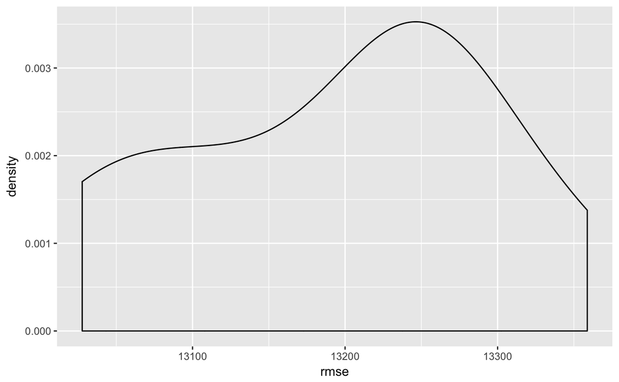

```r
#How do we get a sense of how the model will perform on some unknown test set?
#One slow and complicated way is to write a loop to do this a bunch of times, then aggregate the results.
fold_and_model <- function(dataframe, iterations) {
  #Model will create a fold of 70/30, run model on 70 and calculate RMSE on 30

  #Initialize container for results
  results <- data_frame(rmse = numeric())

  for (i in 1:iterations) {
    test <- sample_frac(df, 0.3)
    train <- filter(df, !index %in% test$index)
    lm <- lm(Weekly_Sales ~ Store + Dept + Date + Type + Size +
                      Temperature + Fuel_Price + CPI + Unemployment + Month + Year,
                    train)
    error <- RMSE(predict(lm, test), test$Weekly_Sales)
    results[i,] <-  error
  }

  print(paste0("The average is ", mean(results$rmse)))
  print(paste0("The std dev is ", sd(results$rmse)))
  ggplot(results, aes(rmse)) + geom_density()
}
fold_and_model(df, 10)
```

```r
#Thus, we are "pretty sure" this model will produce an average error of 13,200 (give or take 100). How can we quantify what we mean by pretty sure?
```

# Confidence Intervals

Remember, statistics is the “science of uncertainty”. It is an attempt at recognizing, quantifying, and communicating insights along with their associated uncertainty. To get an intuition for how uncertainty in models can look, we build a dataframe out of all the test set predictions using the model we built on the train dataset.

```r
#Change proportion of sample size to see what happens to confidence interval
sample_fraction = .001
#Change level of confidence interval
confidence_level = .95
#Predict Sales from Size of Store
size_lm <- lm(Weekly_Sales ~ Size, train)
#Build dataframe of predictions and confidence levels
predictions <- predict(size_lm,
                       test,
                       #interval = "confidence",
                       level = .1,
                       se.fit = T) %>%
  as_tibble %>%
  select(fit, se.fit) %>%
  mutate(upper = fit + qnorm(1 - ((1 - confidence_level) / 2), 0, 1) * se.fit,
         lower = fit - qnorm(1 - ((1 - confidence_level) / 2), 0, 1) * se.fit,
         spread = upper - lower) %>%
  bind_cols(select(test, Size)) %>%
  arrange(Size) %>%
  unique %>%
  arrange(Size) %>%
  select(Size, lower, fit, upper, spread, se.fit)
predictions
```

| Size | lower | fit | upper | spread | se.fit |
| --- | --- | --- | --- | --- | --- |
| 34875 | 6531.601 | 6685.724 | 6839.847 | 308.2461 | 78.63566 |
| 37392 | 6763.037 | 6914.367 | 7065.697 | 302.6602 | 77.21065 |
| 39690 | 6974.320 | 7123.116 | 7271.913 | 297.5939 | 75.91820 |
| 39910 | 6994.546 | 7143.101 | 7291.656 | 297.1106 | 75.79491 |
| 41062 | 7100.456 | 7247.748 | 7395.041 | 294.5851 | 75.15064 |
| 42988 | 7277.514 | 7422.705 | 7567.897 | 290.3824 | 74.07852 |
| 57197 | 8583.321 | 8713.445 | 8843.569 | 260.2482 | 66.39106 |
| 70713 | 9824.540 | 9941.233 | 10057.926 | 233.3863 | 59.53840 |
| 93188 | 11885.555 | 11982.852 | 12080.150 | 194.5953 | 49.64258 |
| 93638 | 11926.771 | 12023.730 | 12120.689 | 193.9186 | 49.46994 |

[output cut: 30 more lines]

Notice that each prediction (“fit”) has a “spread” of uncertainty around it. How can we understand what this “spread” or uncertainty means? In the next visualization, the blue points represent the observations in the train set. A blue linear fit line is plotted along with the blue confidence interval; this represents the best guess of where the points will land in the test set. On top of that, the actual predictions from the test set are plotted in red, along with the errorbars based on their independent confidence intervals.

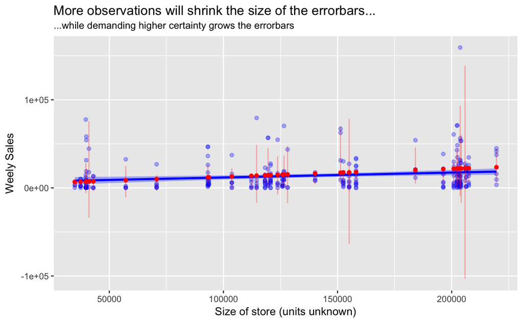

```r
#Experiment with size of sample and confidence level
sample_fraction = .001
confidence_level = .1
#Look at confidence interval of prediction
sample_frac(train, sample_fraction) %>%
  ggplot(aes(Size, Weekly_Sales)) +
    #Plot train dataset
    geom_point(color = "blue", alpha = .3) +
    #Plot confidence interval around line of fit of train data
    geom_smooth(method = "lm", color = "blue", fill = "blue", alpha = .3) +
    #Plot fitted points from test data
    geom_point(data = predictions, aes(Size, fit), color = "red") +
    #Plot error bars on test data set
    stat_summary(geom = "errorbar",
                 fun.data = mean_cl_normal,
                 #width = 0.1,
                 conf.int = confidence_level,
                 color = "red",
                 alpha = .3) +
    labs(title = "More observations will shrink the size of the errorbars...",
         subtitle = "...while demanding higher certainty grows the errorbars",
         x = "Size of store (units unknown)",
         y = "Weely Sales")
```

Let’s also look at the actual variation of the observations around the predictions:

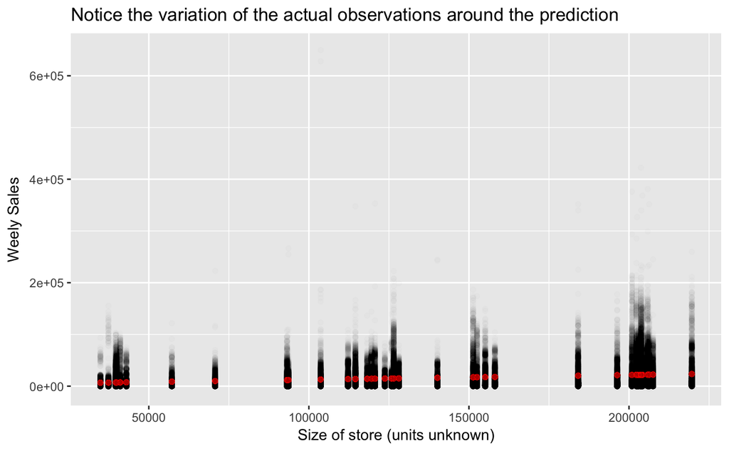